# An Analysis on my 2023 Fantasy Football League (So Far)

- Show All Code
- Hide All Code
- View Source

project

Author

Caleb Hallinan

Published

November 5, 2023

## Brief Introduction

My friends and I are always talking about fantasy football. You may read that and think I’m kidding, but if you look at my phone screen time since football season started the top two are 1. The ESPN Fantasy App and 2. The IPhone Messages App because I am messaging my friends about fantasy. So no, I am not kidding. It’s probably not worth it because I won’t win this year anyways, but eh - it’s fun and I enjoy it :)

[figure not shown]

[ESPN Fantasy App Logo](https://espnpressroom.com/us/press-releases/2016/08/espn-fantasy-footballs-21st-season-comprehensive-coverage-ever/)

**Important**

Fantasy Football can and will likely become addicting if you play, so fair warning to those who have never played before and are interested 😅

```r
# Read in my package ahead of time
library(tidyverse)
library(here)
library(ggplot2)
library(paletteer)
library(stringr)
```

## The Questions and Data

With this being said, I wanted to do a more in depth analysis of some fantasy football statistics so far this year. I did some research and found two awesome blog posts that helped get me started on reading in data and interesting graphs to make [1] [2]. The goal was to answer questions like:

1. How accurate are your weekly projections?
2. What teams are under or over performing each week compared to others?
3. Where do most of the points come from for each team?

My hope is to add more to this analysis as time goes on, so let me know if you have a question you are interested in!

I have two main audiences I want this to reach:

1. My fantasy football friends
2. Others who do fantasy football and might find my analysis interesting

For those of you who may not understand fantasy football, I won’t go into much depth on it so check out this [short post by ESPN](https://www.espn.com/fantasy/football/story/_/id/34389554/fantasy-football-beginners-how-play-fantasy-football-2022) that explains it [3].

So for the data, I decided to use my football fantasy league of this year (2023). I could have done last year for a more complete analysis of how I didn’t win, but this give my league things to talk about now and I can continually update the analysis each week (which seemed pretty cool to me). It turns out I am not the first person that wanted this data, so lucky for me a guy named Tim Bryan made a function to extract all the data from the website [4]. Click [here](https://github.com/tbryan2/espnfantasyfootball) to go to the specific repository I used from him.

However, not everything worked the first try and I had to make some changes to his code to load in all the data without some errors. Feel free to check [my github repo](https://github.com/calebhallinan/fantasy_football_2023) for what I did as well as the data used. So, after some tweeks I was successfully able to read in and save everything I needed to a .csv file in my local directory which I then pushed to my github. Here is a data dictionary for the variables I was using with two different datasets:

Data Dictionary for Scoring Variables

| Variable Name | Data Type | Description | Example |
| --- | --- | --- | --- |
| Week | dbl | Week for each football games played | There are 17 Weeks total |
| PlayerName | chr | Name of football player | Joe Burrow |
| PlayerScoreActual | dbl | The actual points a player scored in a given week | 21.2 |
| PlayerScoreProjected | dbl | The projected points a player is to score in a given week | 19.0 |
| PlayerRosterSlot | chr | What position that player is playing in a given week | WR |
| TeamName | chr | The team who has a given player | Team Caleb (me!) |

Data Dictionary for Weekly Match-up Variables

| Variable Name | Data Type | Description | Example |
| --- | --- | --- | --- |
| Week | dbl | Week for each football games played | There are 17 Weeks total |
| Name1 | chr | Name of team 1 | Team Caleb (me!) |
| Score1 | dbl | The total points Name1 scored in a given week | 102.7 |
| Name2 | chr | Name of team 2 | Team BL |
| Score2 | dbl | The total points Name2 scored in a given week | 121.3 |
| Type | factor | Regular season or Playoff game | Regular |

**Note**

Here is also a brief dictionary for common abbreviations you will see throughout this blog and in fantasy football:

K = Kicker

D/ST = Defense and Special Teams

TE = Tight End

WR = Wide Receiver

RB = Running Back

QB = Quarterback

FLEX = Can be any position listed above

Finally, I de-identified all the data but mine to where my friends would know who they are but no one else can identify them. This data is coming from the ESPN Fantasy Website so thank you to them for allowing me to extract it [5]!

So now, let’s go ahead and read in the data I obtained using python (on my github). I do some pre-processing to remove weeks that haven’t been played yet and other columns I don’t need.

```r
# read in data
data = read_csv("data/league_data_2023_deidentified.csv")

# read in matchup data
matchups = read_csv("data/league_matchups_2023_deidentified.csv")
# get rid of some of the data as it duplicated it
matchups = matchups[1:65,]

# NOTE: edit WEEK based on current week
data = data |>
  # get rid of weeks 9-17
  filter(!Week %in% c(14:17)) |>
  # drop playerfantasyteam
  select(-PlayerFantasyTeam)

matchups = matchups |>
  # get rid of weeks 9-17
  filter(!Week %in% c(14:17))
```

## The Analysis

The first question I wanted to look at was one I was interested coming into this analysis. How accurate are your weekly projections? To me, it seems like they never are haha - I could be projected super high one week and then score 20 points below or vice versa any given week. So let’s look at the plot below:

[figure not shown]

```r
# plot showing weekly projections to actual score
# data
data|>
  # groupby team name and week
  group_by(TeamName, Week)|>
  # get rid of bench players as they don't count towards score
  filter(PlayerRosterSlot != "Bench")|>
  # get the sum of your actual player roster and projected
  summarize(weekly_score = sum(PlayerScoreActual),
            projected_weekly_score = sum(PlayerScoreProjected))|>
  # begin plotting
  ggplot(aes(x = Week, y = weekly_score, color = TeamName)) +
  # add solid line for actual total
  geom_line(aes(linetype = "solid", show.legend = FALSE)) +
  # dashed line for projected total
  geom_line(aes(y = projected_weekly_score, linetype = "dashed")) +
  # add point to easily see week
  geom_point(aes(y=weekly_score), size=1) +
  # average projected
  # geom_hline(aes(yintercept=mean(projected_weekly_score), linetype = "dotted", color="red")) +
  # facet wrap by teamname
  facet_wrap(~ TeamName) +
  # add labels
  labs(
    title = "Weekly Actual and Projected Scores by Team",
    x = "Week",
    y = "Scores",
    caption = "Data Source: ESPN Fantasy Website",
    subtitle = str_wrap("The plot reveals several interesting trends. Notably, Team BD and Team JN consistently maintain
                        a steady average of projected points per week. Meanwhile, teams such as myself and Team BL have
                        experienced a mix of both impressive and lackluster weeks. On the other hand, Team GM has had an
                        incredible season so far, consistently delivering outstanding performances week after week.
                        Lastly, a few teams like Team RW and Team TP have notably underperformed in multiple weeks.",
                        width = 87)) +
  # add manual labels
  scale_linetype_manual(values = c("dashed", "solid"), labels = c("Projected", "Actual")) +
  # set y limit
  ylim(50, 180) +
  # set colors for teams
  scale_colour_manual(values = paletteer_d("ggprism::colors", 12)) +
  # get rid of color legend but use linetype legend
  guides(color = "none", linetype = guide_legend(title = "Scores")) +
  # use classic theme
  theme_classic() +
  # edit text and legend
  theme(axis.text.x = element_text(size = 12),
  axis.text.y = element_text(size = 12),
  plot.title = element_text(face= "bold", hjust = 0.5),
  legend.position = c(.98, -0.12), legend.justification = c(1, 0)) +
  scale_x_continuous(breaks = c(2, 4, 6, 8,10,12))
```

Well, I think I was right in thinking they aren’t ideal but honestly a couple teams seem to follow it fairly well. Team BD is pretty consistent across the board so far, as with Team JN. However, there are some teams with large outlier weeks like Team GM who has had some insane weeks or Team TP who has had some not so great weeks. Overall, it is pretty interesting to see the actual points scored that week compared to the projected!

The next graph is probably my favorite for various reasons and was suggested by one of my friends in this league. What we wanted to look at was how your opponents score that week compared to the weekly average score, or in other words how much your opponent “went off” or “did horribly” compared to others. I then decided to go one step further to plot your score for that week as well, and you can see some really interesting and funny trends in this plot below.

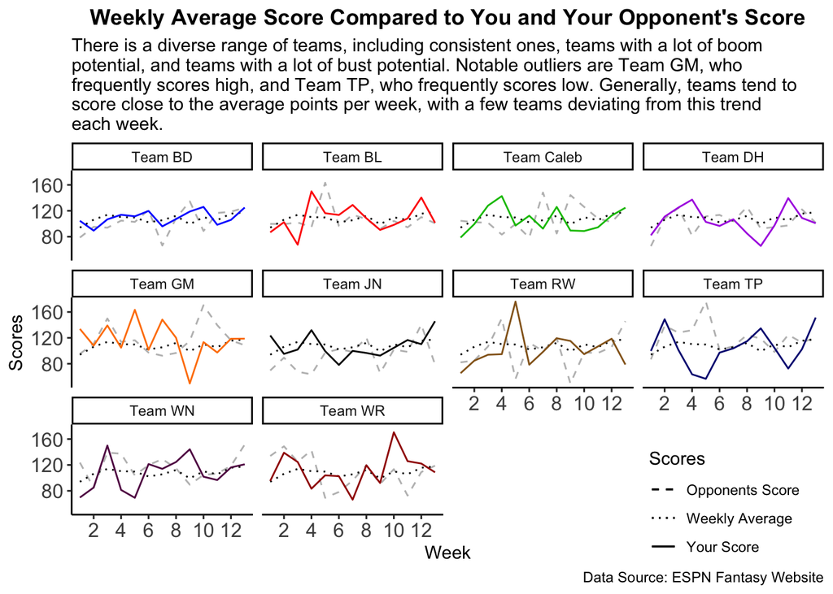

```r
# Points against vs weekly average vs. opponents score
# making new dataframe
weekly_data = data|>
  # group by teamname and week
  group_by(TeamName, Week)|>
  # get rid of bench players
  filter(PlayerRosterSlot != "Bench")|>
  # get projected and weekly score for each team
  summarize(weekly_score = sum(PlayerScoreActual),
            projected_weekly_score = sum(PlayerScoreProjected))

# get points against using an inner join between weekly data and matchups data
# this is so I know who is playing who each week
pts_against = inner_join(weekly_data, matchups, by = c("Week")) |>
  # had to only keep rows with the teamname of the week looked at
  filter(TeamName == Name1 | TeamName == Name2)

# add a column that is your opponent for that week
pts_against$opponent = ifelse(pts_against$TeamName == pts_against$Name1, pts_against$Name2,pts_against$Name1)
# get the opponents score for that week
pts_against$opponent_score = ifelse(pts_against$TeamName == pts_against$Name1, pts_against$Score2,pts_against$Score1)

# redfine dataframe
pts_against = pts_against |>
  # select only handful of columns now that are needed for plot
  select(TeamName, Week, weekly_score, projected_weekly_score, opponent, opponent_score) |>
  # group by week
  group_by(Week) |>
  # get mean weekly average to plot as well
  mutate(weekly_average = mean(weekly_score))

# init plot
ggplot(pts_against, aes(x = Week, color = TeamName)) +
  # geom line for opponent score
  geom_line(aes(y = opponent_score, linetype = "dashed"), color= "gray") +
  # geom line for weekly average score
  geom_line(aes(y = weekly_average, linetype = "dotted"), color= "black") +
  # geom line for your score
  geom_line(aes(y = weekly_score, linetype = "solid")) +
  # wrap by team
  facet_wrap(.~ TeamName) +
  # set labs
  labs(
    title = "Weekly Average Score Compared to You and Your Opponent's Score",
    x = "Week",
    y = "Scores",
    caption = "Data Source: ESPN Fantasy Website",
    subtitle = str_wrap("There is a diverse range of teams, including consistent ones, teams with a lot of boom
                        potential, and teams with a lot of bust potential. Notable outliers are Team GM, who
                        frequently scores high, and Team TP, who frequently scores low. Generally, teams tend to
                        score close to the average points per week, with a few teams deviating from this trend each
                        week.", width = 90)) +
  # set custom labels for linetype
  scale_linetype_manual(values = c("dashed", "dotted", "solid"), labels = c("Opponents Score", "Weekly Average", "Your Score")) +
  # set colors for teamnames
  scale_colour_manual(values = paletteer_d("ggprism::colors", 12)) +
  # get only legend for linetype
  guides(color = "none", linetype = guide_legend(title = "Scores")) +
  # theme classe
  theme_classic() +
  # edit text and legend position
  theme(axis.text.x = element_text(size = 12),
  axis.text.y = element_text(size = 12),
  plot.title = element_text(face= "bold", hjust = 0.5),
  legend.position = c(.98, -.16), legend.justification = c(1, 0)) +
  scale_x_continuous(breaks = c(2, 4, 6, 8, 10,12))
```

A lot of these trends can be explained more by BYE weeks (weeks that a NFL team has off), injuries, or injuries that affect other players (for example, QB Matt Stafford was out Week 9 and so WR Puka Nacua didn’t even score 5 points when he was projected 12). I think that is certainly the case for Team TP who has had a tough go at injuries this season. I personally have had a decent amount, like the number one overall pick Justin Jefferson being on IR and missing the past 4 weeks (note the drop in my score four weeks ago) 🙃.